# Instalación de softwares en GNU/LINUX

Antony Barja

2020-04-19

[figure not shown]

### Autor : [Antony Barja](https://barja8.github.io/)

Un procedimiento indispensable para poder cumplir con todo los objetivos planteados en este repositorio es la instalación de softwares con la cual vamos ir trabajando y resolviendo algunos ejercicios planteados durante las respectivas sesiones, para poder obtener los mismos resultados es importante tener los mismos softwares con las mismas configuraciones y la base de datos con la cual vamos trabajar las diferentes combinaciones de comandos **SQL**.

Como primeros pasos vamos a proceder a instalar los respectivos softwares:

- [**VisualCode**](https://code.visualstudio.com)
- [**PostgreSQL**](https://www.postgresql.org)
- [**PostGIS**](https://postgis.net)
- [**PgAdmin**](https://www.pgadmin.org)
- [**QGIS**](https://qgis.org/es/site/)

# VisualCode

Es un ligero pero poderoso editor de código multiplataforma (Windows, macOS, GNU/Linux) que posee un gran ecosistemas de extensiones para dar soportes a varios tipos de lenguajes de programación y de desarrollo web, entre ellas destaca **Python**, **R**, **Html**, **Css**, **JavaScript**, **Node.js** ,**Go**, entre otros.

# Instalación de VisualCode

Para poder instalar VisualCode en **GNU/Linux**, primero tenemos que saber la distribución con la cual estamos trabajando, para esto nos dirigimos hacia la consola y editamos el siguiente comando:

```
antony$antony:~$ cat /etc/*-release
```

```
DISTRIB_ID=Ubuntu
DISTRIB_RELEASE=19.10
DISTRIB_CODENAME=eoan
DISTRIB_DESCRIPTION="Ubuntu 19.10"
NAME="Ubuntu"
VERSION="19.10 (Eoan Ermine)"
ID=ubuntu
ID_LIKE=debian
PRETTY_NAME="Ubuntu 19.10"
VERSION_ID="19.10"
HOME_URL="https://www.ubuntu.com/"
SUPPORT_URL="https://help.ubuntu.com/"
BUG_REPORT_URL="https://bugs.launchpad.net/ubuntu/"
PRIVACY_POLICY_URL="https://www.ubuntu.com/legal/terms-and-policies/privacy-policy"
VERSION_CODENAME=eoan
UBUNTU_CODENAME=eoan
```

Una vez identificado el tipo de distribución procedemos a instalar el software mediante los siguientes comandos:

```
sudo apt update
sudo apt install software-properties-common apt-transport-https wget
wget -q https://packages.microsoft.com/keys/microsoft.asc -O- | sudo apt-key add -
sudo add-apt-repository "deb [arch=amd64] https://packages.microsoft.com/repos/vscode stable main"
sudo apt install code
```

Finalmente para comprobar que la instalación fue exitosa procedemos iniciar el software cómo se muestra en la siguiente imagen.

[figure not shown]

# PostgreSQL - PostGIS

**PostgreSQL** es un potente sistema de gestión de base de datos relacional orientado a objetos de código abierto con más de 30 años de desarrollo activo.

**PostGIS** es un extención PostgreSQL que da soporte al manejo de datos geográficos,y permite que las consultas de ubicación se ejecuten mediante comandos de SQL.

# Instalación de PostgreSQL-PostGIS

Para poder instalar PostgreSQL y PostGIS, primero debemos verificar si versión de ambos softwares están disponibles para el tipo de distribución de GNU/Linux que estamos utilizando, para esto puedes encontrar más detalle en el siguiente enlace [clic aquí](https://ubuntu.pkgs.org/19.10/ubuntu-universe-i386/postgresql-11-postgis-2.5-scripts_2.5.3+dfsg-1_all.deb.html).

Para nuestra distribución de Ubuntu sólo tenemos que emplear los siguientes comandos:

```
 sudo apt-get update
 sudo apt-get install postgresql-11-postgis-2.5-scripts
```

Para verificar que la instación fue correcta procedemos a tipear los siguientes comandos

```
psql --version
```

```
sudo -i -u postgres
createuser postgis_test
createdb postgis_db postgis_test
psql -d postgis_db
postgis_db=# CREATE EXTENSION postgis;
postgis_db=# SELECT PostGIS_version();
```

# PgAdmin

Es una plataforma de administración y desarrollo de código abierto para PostgreSQL

# Instalación de PgAdmin

```
sudo apt-get install wget ca-certificates
wget --quiet -O - https://www.postgresql.org/media/keys/ACCC4CF8.asc | sudo apt-key add -

sudo sh -c 'echo "deb http://apt.postgresql.org/pub/repos/apt/ `lsb_release -cs`-pgdg main" >> /etc/apt/sources.list.d/pgdg.list'
```

```
sudo apt-get update
sudo apt install pgadmin4 pgadmin4-apache2
```

*Observación: Si olvidas cual es tu password de tu cuenta de postgres con este comando puedes crear una nueva contraseña*

```
sudo passwd postgres
```

Finalmente para verificar que la instalación fue exitosa procedemos abrir el software

[figure not shown]

[figure not shown]

[figure not shown]

# QGIS

Es un software de Sistema de Información Geográfica libre y de codigo abierto orientado al manejo, análisis, edición y representación de datos espaciales.

# Instalación de **QGIS 3.X**

La instalación de QGIS va a depender del tipo de distribución GNU/Linux con la cual estamos trabajando, para nuestro caso es **Ubuntu 19.10 eoan**, entonces para instalar **QGIS** sólo debemos emplear los siguientes comandos:

```
sudo nano /etc/apt/sources.list
```

```
deb     https://qgis.org/ubuntu eoan main
deb-src https://qgis.org/ubuntu eoan main
```

[output not shown]

```
sudo apt-get update
sudo apt-get install qgis qgis-plugin-grass
sudo apt install saga
```

Para verificar que la instalación fue exitosa procedemos a iniciar QGIS

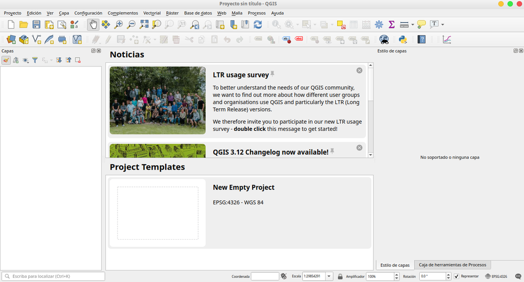